# KAGGLE: Intro to machine learning

##### PANDAS

Here are some code snippets that are need to get started pandas

```python
import pandas as pd
dataset = "S:\playing with data with python\kaggle course for _intro to machine learning_\Machine_learning_kaggle\iris.csv"  #use this to assign the data set to a variable.
data=pd.read_csv(dataset)                 #use this to read the dataset into a variable.
descp=data.describe()                           #This function returns the essential info like mean, median, percentile,
                                          #and the columns.
#data.columns()                            #retuns the columns in the dataset
clean_data = data.dropna(axis=0)          #dropna drops the missing values
print(descp)
```

```
               Id  SepalLengthCm  SepalWidthCm  PetalLengthCm  PetalWidthCm  \
count  150.000000     150.000000    150.000000     150.000000    150.000000
mean    75.500000       5.843333      3.054000       3.758667      1.198667
std     43.445368       0.828066      0.433594       1.764420      0.763161
min      1.000000       4.300000      2.000000       1.000000      0.100000
25%     38.250000       5.100000      2.800000       1.600000      0.300000
50%     75.500000       5.800000      3.000000       4.350000      1.300000
75%    112.750000       6.400000      3.300000       5.100000      1.800000
max    150.000000       7.900000      4.400000       6.900000      2.500000

          Species
count  150.000000
mean     1.000000
std      0.819232
min      0.000000
25%      0.000000
50%      1.000000
75%      2.000000
max      2.000000
```

### Selecting The Prediction Target

You can pull out a variable with dot-notation. This single column is stored in a Series, which is broadly like a DataFrame with only a single column of data. We'll use the dot notation to select the column we want to predict, which is called the prediction target. By convention, the prediction target is called y.

```python
y =data.Species                         #Selects the prediction target with the dot operator
print (y)
```

```
0      0
1      0
2      0
3      0
4      0
      ..
145    2
146    2
147    2
148    2
149    2
Name: Species, Length: 150, dtype: int64
```

##### Here 0, 1, 2 represent one of the three species of iris

### Choosing "Features"

The columns that are inputted into our model (and later used to make predictions) are called "features." We select multiple features by providing a list of column names inside brackets. Each item in that list should be a string (with quotes).

```python
iris_features=['SepalLengthCm','SepalWidthCm','PetalLengthCm','PetalWidthCm']         #this stores the dependent variables
X=data[iris_features]                                                                 #stores the features in a X variable
X.describe()
```

|  | SepalLengthCm | SepalWidthCm | PetalLengthCm | PetalWidthCm |
| --- | --- | --- | --- | --- |
| count | 150.000000 | 150.000000 | 150.000000 | 150.000000 |
| mean | 5.843333 | 3.054000 | 3.758667 | 1.198667 |
| std | 0.828066 | 0.433594 | 1.764420 | 0.763161 |
| min | 4.300000 | 2.000000 | 1.000000 | 0.100000 |
| 25% | 5.100000 | 2.800000 | 1.600000 | 0.300000 |
| 50% | 5.800000 | 3.000000 | 4.350000 | 1.300000 |
| 75% | 6.400000 | 3.300000 | 5.100000 | 1.800000 |
| max | 7.900000 | 4.400000 | 6.900000 | 2.500000 |

```python
X.head()                                                 #displays the head rows
```

|  | SepalLengthCm | SepalWidthCm | PetalLengthCm | PetalWidthCm |
| --- | --- | --- | --- | --- |
| 0 | 5.1 | 3.5 | 1.4 | 0.2 |
| 1 | 4.9 | 3.0 | 1.4 | 0.2 |
| 2 | 4.7 | 3.2 | 1.3 | 0.2 |
| 3 | 4.6 | 3.1 | 1.5 | 0.2 |
| 4 | 5.0 | 3.6 | 1.4 | 0.2 |

### Building Your Model (Using Decision Tree Regressor)

You will use the scikit-learn library to create your models. When coding, this library is written as sklearn, as you will see in the sample code. Scikit-learn is easily the most popular library for modeling the types of data typically stored in DataFrames.

##### The steps to building and using a model are:

Define: What type of model will it be? A decision tree? Some other type of model? Some other parameters of the model type are specified too.  
**Fit**: Capture patterns from provided data. This is the heart of modeling.  
**Predict**: Just what it sounds like  
**Evaluate**: Determine how accurate the model's predictions are.

##### We will be using the scikit learn library to implement our models

```python
from sklearn.tree import DecisionTreeRegressor
iris_model=DecisionTreeRegressor(random_state=1)
iris_model.fit(X, y)                              #This line has been commented as decission tree will not work here
```

```
DecisionTreeRegressor(criterion='mse', max_depth=None, max_features=None,
                      max_leaf_nodes=None, min_impurity_decrease=0.0,
                      min_impurity_split=None, min_samples_leaf=1,
                      min_samples_split=2, min_weight_fraction_leaf=0.0,
                      presort=False, random_state=1, splitter='best')
```

Here we have used the Decission tree model from scikit learn.  
You can study yourself about he decission tree model.

### MAKE PREDICTIONS

```python
print ("Making predictions on this :")
X.head()
```

```
Making predictions on this :
```

|  | SepalLengthCm | SepalWidthCm | PetalLengthCm | PetalWidthCm |
| --- | --- | --- | --- | --- |
| 0 | 5.1 | 3.5 | 1.4 | 0.2 |
| 1 | 4.9 | 3.0 | 1.4 | 0.2 |
| 2 | 4.7 | 3.2 | 1.3 | 0.2 |
| 3 | 4.6 | 3.1 | 1.5 | 0.2 |
| 4 | 5.0 | 3.6 | 1.4 | 0.2 |

```python
print ("the predicted values are:")
model_predictions=iris_model.predict(X)
print(model_predictions)
```

```
the predicted values are:
[0. 0. 0. 0. 0. 0. 0. 0. 0. 0. 0. 0. 0. 0. 0. 0. 0. 0. 0. 0. 0. 0. 0. 0.
 0. 0. 0. 0. 0. 0. 0. 0. 0. 0. 0. 0. 0. 0. 0. 0. 0. 0. 0. 0. 0. 0. 0. 0.
 0. 0. 1. 1. 1. 1. 1. 1. 1. 1. 1. 1. 1. 1. 1. 1. 1. 1. 1. 1. 1. 1. 1. 1.
 1. 1. 1. 1. 1. 1. 1. 1. 1. 1. 1. 1. 1. 1. 1. 1. 1. 1. 1. 1. 1. 1. 1. 1.
 1. 1. 1. 1. 2. 2. 2. 2. 2. 2. 2. 2. 2. 2. 2. 2. 2. 2. 2. 2. 2. 2. 2. 2.
 2. 2. 2. 2. 2. 2. 2. 2. 2. 2. 2. 2. 2. 2. 2. 2. 2. 2. 2. 2. 2. 2. 2. 2.
 2. 2. 2. 2. 2. 2.]
```

### What is model validation

#### Using mean_absolute_error

Model validation refers to accuracy of the model or how well the model  
behaves to outside realworld data. We will be using the mean_absolute_error here.

```python
from sklearn.metrics import mean_absolute_error
mean_absolute_error(y,model_predictions)
```

```
0.0
```

We see here the error on the trained data is zero.  
This is because the model performs well on the data that it has been trained upon.  
This is known as in sample scores. This problem need to be solved by splitting the data into train and testing data.

### train_test_split

```python
from sklearn.model_selection import train_test_split
train_X, val_X, train_y, val_y= train_test_split(X,y,random_state=0)
model=DecisionTreeRegressor(random_state=1)
model.fit(train_X, train_y)
model_predictions_on_val_X=model.predict(val_X)
mean_absolute_error(val_y,model_predictions_on_val_X)*100
```

```
2.631578947368421
```

## Problem with underffitting and overfitting

This is a phenomenon called **overfitting**, where a model matches the training data almost perfectly, but does poorly in validation and other new data.

When a model fails to capture important distinctions and patterns in the data, so it performs poorly even in training data, that is called **underfitting**.

[figure not shown]

We require the sweet spot between the underfitting and overfitting part of the curve

There are a few alternatives for controlling the tree depth, and many allow for some routes through the tree to have greater depth than other routes. But the **max_leaf_nodes** argument provides a very sensible way to control overfitting vs underfitting. The more leaves we allow the model to make, the more we move from the underfitting area in the above graph to the overfitting area. We can use a utility function to help compare MAE scores from different values for max_leaf_nodes:

*So we shall create a function that will return the MAE scores for various max_node_leaf (iterrated by a loop) and find the optimal sweet point that we talked earlier about*

```python
import matplotlib.pyplot as plt
from sklearn.metrics import mean_absolute_error
from sklearn.tree import DecisionTreeRegressor
def model_fit_index(max_leaf_nodes,train_X, val_X, train_y, val_y):
    model = DecisionTreeRegressor(max_leaf_nodes=max_leaf_nodes,random_state=0)
    model.fit(train_X, train_y)
    model_predictions_on_val_X=model.predict(val_X)
    mae_index=mean_absolute_error(val_y,model_predictions_on_val_X)*100
    return (mae_index)
```

```
2 33.75438596491228
3 13.495276653171388
4 4.94264507422402
5 2.9689608636977045
6 2.631578947368421
7 2.631578947368421
8 2.631578947368421
9 2.631578947368421
10 2.631578947368421
11 2.631578947368421
12 2.631578947368421
13 2.631578947368421
14 2.631578947368421
```

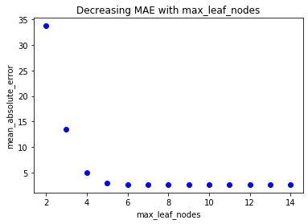

```python
mae_score_ar=[]
i=0
for max_leaf_nodes in range(2,15):
    mae_score=model_fit_index(max_leaf_nodes,train_X, val_X, train_y, val_y)
    mae_score_ar.append(mae_score)
    print(max_leaf_nodes,mae_score)
    plt.plot(max_leaf_nodes,mae_score_ar[i],'bo')
    i=i+1

plt.title("Decreasing MAE with max_leaf_nodes")
plt.xlabel("max_leaf_nodes")
plt.ylabel("mean_absolute_error")
plt.show()
    #print("Max leaf nodes: %d  \t\t Mean Absolute Error:  %d" %(max_leaf_nodes, mae_score))
```

from here we can see that the best result is given at **max_leaf_node**= 6 . This dataset is so small in  
variation that we can easily minimize the mean absolute error  
Use this value to fine tune the model.Here there is no problem of the model getting overfitted

## Random Tree

#### Using the RandomForestRegressor

```python
from sklearn.ensemble import RandomForestRegressor
from sklearn.metrics import mean_absolute_error

forest_model = RandomForestRegressor(random_state=1)
forest_model.fit(train_X, train_y)
melb_preds = forest_model.predict(val_X)
print(mean_absolute_error(val_y, melb_preds)*100)
```

```
6.578947368421052
```

[output not shown]

There are parameters which can be modified to fine tune the RandomForest model.  
But Random Forest models work reasonably well without any further modification. **XGBoost** is another good model which works really well when fine tuned with the right parameteres.